# Lab 06 - Text Mining

Author

Arianna Hernandez

# **Lab 06 - Text Mining**

```
knitr::opts_chunk$set(eval = FALSE, include  = TRUE)
```

# **Learning goals**

- Use `unnest_tokens()` and `unnest_ngrams()` to extract tokens and ngrams from text.
- Use dplyr and ggplot2 to analyze text data

# **Lab description**

For this lab we will be working with a new dataset. The dataset contains transcription samples from https://www.mtsamples.com/. And is loaded and “fairly” cleaned at https://raw.githubusercontent.com/USCbiostats/data-science-data/master/00_mtsamples/mtsamples.csv.

### **Setup packages**

You should load in `dplyr`, (or `data.table` if you want to work that way), `ggplot2` and `tidytext`. If you don’t already have `tidytext` then you can install with

```
install.packages("tidytext")
```

### **read in Medical Transcriptions**

Loading in reference transcription samples from https://www.mtsamples.com/

```
# A tibble: 6 × 3
  description                                    medical_specialty transcription
  <chr>                                          <chr>             <chr>
1 A 23-year-old white female presents with comp… Allergy / Immuno… "SUBJECTIVE:…
2 Consult for laparoscopic gastric bypass.       Bariatrics        "PAST MEDICA…
3 Consult for laparoscopic gastric bypass.       Bariatrics        "HISTORY OF …
4 2-D M-Mode. Doppler.                           Cardiovascular /… "2-D M-MODE:…
5 2-D Echocardiogram                             Cardiovascular /… "1.  The lef…
6 Morbid obesity.  Laparoscopic antecolic anteg… Bariatrics        "PREOPERATIV…
```

## **Question 1: What specialties do we have?**

We can use `count()` from `dplyr` to figure out how many different categories do we have? Are these catagories related? overlapping? evenly distributed?{.underline}

```r
mt_samples %>%
  count(medical_specialty, sort = TRUE)
```

```
# A tibble: 40 × 2
   medical_specialty                 n
   <chr>                         <int>
 1 Surgery                        1103
 2 Consult - History and Phy.      516
 3 Cardiovascular / Pulmonary      372
 4 Orthopedic                      355
 5 Radiology                       273
 6 General Medicine                259
 7 Gastroenterology                230
 8 Neurology                       223
 9 SOAP / Chart / Progress Notes   166
10 Obstetrics / Gynecology         160
# ℹ 30 more rows
```

We get 40 specialty types, with some overlap in categories– for example we have “discharge summary”,“office notes”, “SOAP/Chart/Progress Notes”. These all seem to relate in a way and are not necessarily medical specialties. Aditionally, we can see “General Medicine” and “Consult”, which seem to overlap as well.

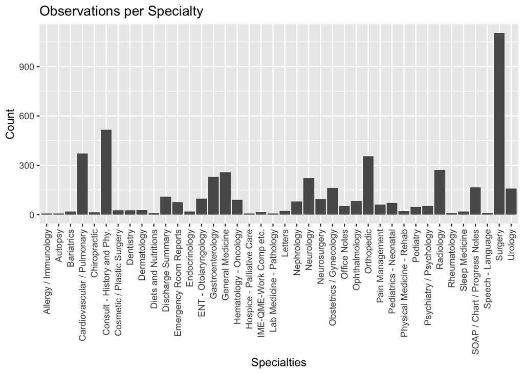

```r
mt_samples %>%
  ggplot()+
  geom_bar(aes( x = medical_specialty)) +
  theme(axis.text.x = element_text(angle = 90, hjust = 1, vjust = 0.5)) +
  labs(title = "Observations per Specialty",
       x = "Specialties",
       y = "Count")
```

## **Question 2**

- Tokenize the the words in the `transcription` column
- Count the number of times each token appears

```r
mt_samples %>%
  unnest_tokens(word, transcription) %>%
  count(word, sort = TRUE)
```

```
# A tibble: 23,647 × 2
   word         n
   <chr>    <int>
 1 the     149888
 2 and      82779
 3 was      71765
 4 of       59205
 5 to       50632
 6 a        42810
 7 with     35815
 8 in       32807
 9 is       26378
10 patient  22065
# ℹ 23,637 more rows
```

- Visualize the top 20 most frequent words

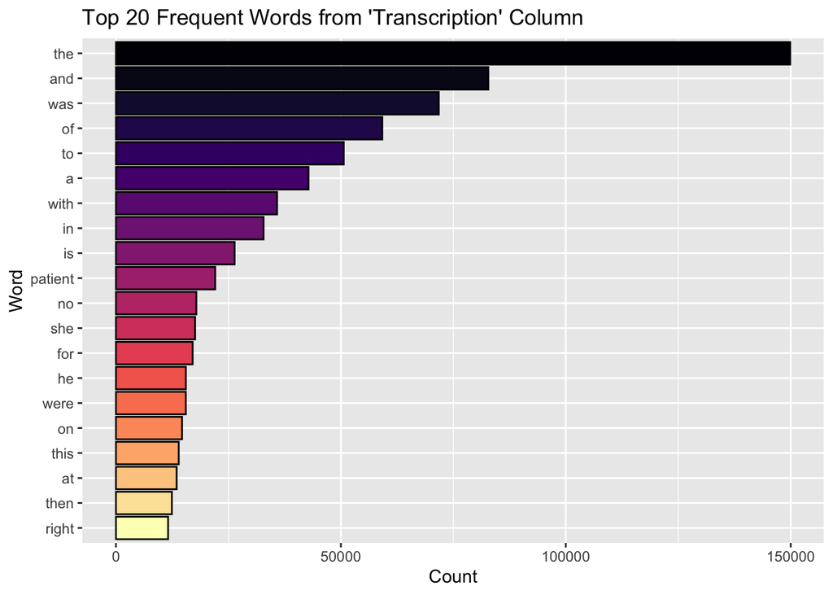

```r
mt_samples %>%
  unnest_tokens(word, transcription) %>%
  count(word, sort = TRUE)  %>%
  top_n(20, n)  %>%
  ggplot(aes(n, fct_reorder(word, n))) +
  geom_col(color = 'black', fill = viridis::magma(20)) +
  labs(title = "Top 20 Frequent Words from 'Transcription' Column",
       x = "Count",
       y = "Word")
```

Explain what we see from this result. Does it makes sense? What insights (if any) do we get?{.underline}

## We see that the majority of words are “the”, “and”, “was”. Knowing that we’re talking about medical records, the only word related is “Patient” about halfway down the records. This visualization does not give us much insight and further breakdown of the words is necessary to see anything in the data.

## **Question 3**

- Redo visualization but remove stopwords before
- Bonus points if you remove numbers as well

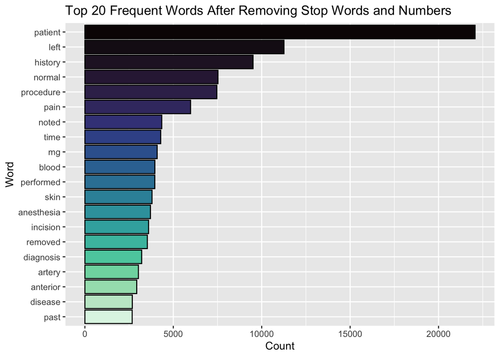

```r
mt_samples %>%
  unnest_tokens(word, transcription) %>%
  anti_join(stop_words, by = c("word")) %>%
  filter(!stringr::str_detect(word, "^[0-9]+$")) %>%
  count(word, sort = TRUE) %>%
  top_n(20, n) %>%
  ggplot(aes(n, fct_reorder(word, n))) +
  geom_col(color = 'black', fill = viridis::mako(20)) +
  labs(title = "Top 20 Frequent Words After Removing Stop Words and Numbers",
       x = "Count",
       y = "Word")
```

What do we see know that we have removed stop words? Does it give us a better idea of what the text is about?{.underline}

Once removing stop words and numbers, we can get a much bettwe idea about the text. From these words, we can see that it is healthcare/medical related.

# **Question 4**

repeat question 2, but this time tokenize into bi-grams.{.underline}

```r
mt_samples %>%
  unnest_ngrams(ngram, transcription, n = 2) %>%
  count(ngram, sort = TRUE)
```

```
# A tibble: 301,419 × 2
   ngram           n
   <chr>       <int>
 1 the patient 20307
 2 of the      19062
 3 in the      12790
 4 to the      12374
 5 was then     6956
 6 and the      6350
 7 patient was  6293
 8 the right    5509
 9 on the       5241
10 the left     4860
# ℹ 301,409 more rows
```

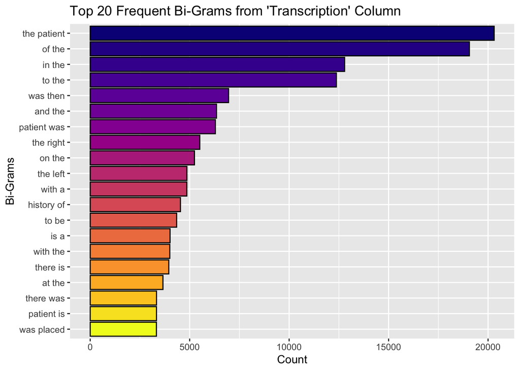

```r
mt_samples %>%
  unnest_ngrams(ngram, transcription, n = 2) %>%
  count(ngram, sort = TRUE) %>%
  top_n(20, n)  %>%
  ggplot(aes(n, fct_reorder(ngram, n))) +
  geom_col(color = 'black', fill = viridis::plasma(20))+
  labs(title = "Top 20 Frequent Bi-Grams from 'Transcription' Column",
       x = "Count",
       y = "Bi-Grams")
```

How does the result change if you look at tri-grams?{.underline}

```r
mt_samples %>%
  unnest_ngrams(ngram, transcription, n = 3) %>%
  count(ngram, sort = TRUE)
```

```
# A tibble: 655,442 × 2
   ngram                  n
   <chr>              <int>
 1 the patient was     6104
 2 the patient is      3075
 3 as well as          2243
 4 there is no         1678
 5 the operating room  1532
 6 patient is a        1491
 7 prepped and draped  1490
 8 was used to         1480
 9 and draped in       1372
10 at this time        1333
# ℹ 655,432 more rows
```

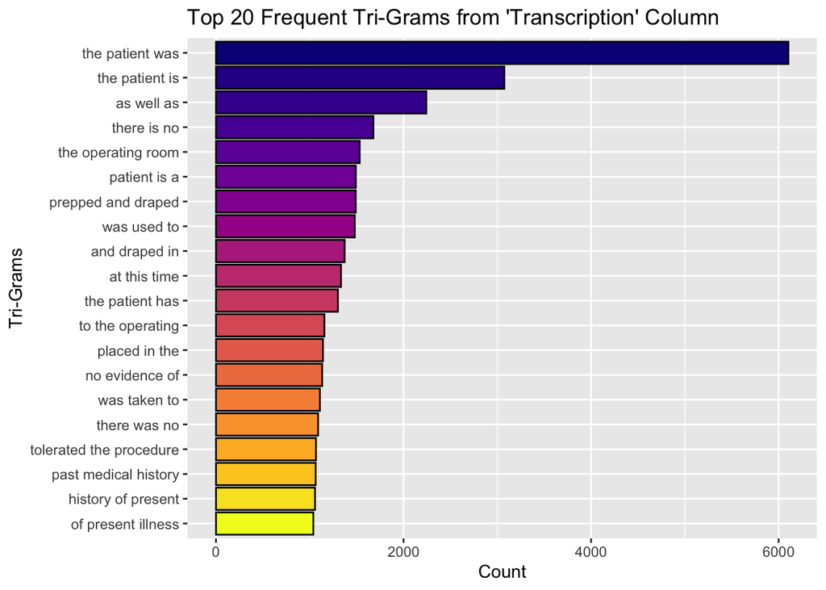

```r
mt_samples %>%
  unnest_ngrams(ngram, transcription, n = 3) %>%
  count(ngram, sort = TRUE) %>%
  slice_max( n, n = 20, with_ties = FALSE)  %>%
  ggplot(aes(n, fct_reorder(ngram, n))) +
  geom_col(color = 'black', fill = viridis::plasma(20)) +
  labs(title = "Top 20 Frequent Tri-Grams from 'Transcription' Column",
       x = "Count",
       y = "Tri-Grams")
```

# **Question 5**

Using the results you got from questions 4. Pick a word and count the words that appears after and before it.{.underline}

```r
mt_samples %>%
  unnest_ngrams(ngram, transcription, n=2) %>%
  separate(ngram, into=c("word1", "word2", sep=" ")) %>%
  select(word1, word2) %>%
  filter(word1 == "anesthesia") %>%
  count(word2, sort=TRUE) ##word after
```

```
# A tibble: 212 × 2
   word2          n
   <chr>      <int>
 1 general      781
 2 was          555
 3 the          324
 4 and          217
 5 local        133
 6 a             91
 7 with          86
 8 care          72
 9 spinal        65
10 department    55
# ℹ 202 more rows
```

```r
mt_samples %>%
  unnest_ngrams(ngram, transcription, n=2) %>%
  separate(ngram, into=c("word1", "word2", sep=" ")) %>%
  select(word1, word2) %>%
  filter(word2 == "anesthesia") %>%
  count(word1, sort=TRUE) ##word before
```

```
# A tibble: 446 × 2
   word1            n
   <chr>        <int>
 1 general        480
 2 endotracheal   370
 3 of             319
 4 local          117
 5 the            113
 6 and             78
 7 by              78
 8 under           77
 9 from            67
10 monitored       54
# ℹ 436 more rows
```

# **Question 6**

Which words are most used in each of the specialties. you can use `group_by()` and `top_n()` from `dplyr` to have the calculations be done within each specialty. Remember to remove stopwords. How about the most 5 used words?{.underline}

```r
mt_samples %>%
  unnest_tokens(word, transcription) %>%
  group_by(medical_specialty) %>%
  anti_join(stop_words, by = c("word")) %>%
  filter(!stringr::str_detect(word, "^[0-9]+$")) %>%
  count(word, sort = TRUE) %>%
  top_n(5, n) %>%
  arrange(medical_specialty, desc(n))
```

```
# A tibble: 210 × 3
# Groups:   medical_specialty [40]
   medical_specialty    word          n
   <chr>                <chr>     <int>
 1 Allergy / Immunology history      38
 2 Allergy / Immunology noted        23
 3 Allergy / Immunology patient      22
 4 Allergy / Immunology allergies    21
 5 Allergy / Immunology nasal        13
 6 Allergy / Immunology past         13
 7 Autopsy              left         83
 8 Autopsy              inch         59
 9 Autopsy              neck         55
10 Autopsy              anterior     47
# ℹ 200 more rows
```